# MAD – Data Analysis & Biostatistics in R

Chapter 5 - RStudio Projects and Documents

James R. Hunter, Ph.D.

DIPA, EPM, UNIFESP

2020-08-18

One of the important preliminaries to preparing analyses and creating reports is to learn how to take advantage of the resources of RStudio, especially as they ease your work flow considerably and create documents that you can submit for this course and in your regular work. Any document I write for the Retrovirology Laboratory that involves analysis gets prepared here, in “rmd” (“R Markdown”) format in RStudio. RStudio also has a project capability, which will help you keep track of the various different projects and analyses you are working on.

# RStudio Projects

When we start a new research project, we always have good intentions. We promise to ourselves that we keep all our files organized so we don’t suffer later (for example, tomorrow) when we return to work on our data again. Of course, we don’t manage to do that. In these times in which there is increased emphasis on reproducibility in science, project organization has become even more important. Every article, study, poster or good idea needs its own space on your computer that keeps it from being confused with other projects.

Putting this idea of organization in practice is another thing. To accomplish this, we need to think a bit about our workflow. We receive files from sequencers and other machines. We create data files by hand or from other data sources (e.g., government data bases). You have tables, charts, text files, article copies. In a medium-sized project, you could easily have 500 or more files. Remembering where all of them are located and what their names mean can intimidate the best organized researcher.

The simple solution of throwing everything about a project into a single directory (*pasta*) works for the first few days, but as the number of files climbs, it rapidly becomes unworkable. As well, every time you start RStudio, you need to navigate over to where this directory is located and make it the *working directory*. You can find out what is your working directory at any time with the `getwd()` function.[^1]

```r
getwd()
```

```
## [1] "C:/Users/james/OneDrive/Documents/MAD/MAD-Infecto-2020/Chapters"
```

The working directory is the last element (i.e., after the last “/”) in the sequence of directories. However, there is a problem. Not everyone in your working group will have the same directory structure as you. Clearly, no one else with whom I’m working will have the `james` subdirectory unless their name is the same as mine. Using this type of directory structure involves a lot of copy/pasting every time you need to locate a file for reading or writing. Not cool.

## What is an RStudio Project?

RStudio has created a system that allows you to manage all your different projects with distinct names and spaces. A project in RStudio saves all the project files together, but separated from all the other files in your computer, in a directory that is only for the project on which you are working. When you establish a new project or switch from one project to another, RStudio will start a new instance (*copy*) of itself so what you do on this project is always separate from your other projects.

You can even have multiple projects open at the same time. They will be located in separate instances of RStudio. However, if you have a computer with limited memory (< 4GB), it is probably not a good idea to have more than one project open at any one time.

One of the advantages of RStudio projects is that they fix the different directory structure problem among team members that I discussed above. When you create a project, the directory it makes the active directory will mostly resolve the problem of potentially conflicting directory names. Some R wizards believe this is so important that one of them (Professor Jenny Bryan of the University of British Columbia who is also an RStudio employee) said in a presentation:

> If the first line of your R script is

> `setwd("C:\Users\jenny\path\that\only\I\have")`

> I will come into your office and SET YOUR COMPUTER ON FIRE

**VSS:** The best way to avoid Prof. Bryan’s ultimate punishment is to create a new RStudio project for each new activity you want to undertake.

## Create a New Project

At the top right of your screen, above the tabs for “Environment, History, …”, you will see an RStudio logotype with the text “Project:(None)” and an arrow that you can click.

[figure not shown]

This text shows that there is no active project. We can create a new project by clicking on the little arrow. A drop-down menu will appear, on which you will find a “New Project…” option. If you previously created projects and want to use one of them, you can click on them.

[figure not shown]

Select *New Project*. This will open a window that lets you select where you want to put your project on your drive (hard or cloud). You can choose to create a new directory or place it in an existing directory. If you already have created a directory for the new project, use this second option to place the R-related files there.

[figure not shown]

In our case, we will create a new directory, so we click on that menu item. There are a variety of types of project you can create in RStudio. However, we want just a garden-variety “New Project”, so we select that option.

[figure not shown]

This choice will take you to the following screen where you give the project a name and a location.

[figure not shown]

For this example, I gave the project the name “test_proj”. When you click the `Create Project` button, the system will create a new directory with this name, which will be a sub-directory of `~/Documents/MAD`. While this directory name and location works for my computer, you can choose any project name and location that fits your directory structure.

You will see check boxes in the window that relate to *git* and *packrat*, two ways of controlling the versions of your programs and the packages you will make use of. For now, you should leave these blank. When you click on the `Create Project` button, a new instance of RStudio will load with the name of your new project in the upper right location. You will also see that RStudio has created a file `test_proj.Rproj` in the `Files` tab on the right side of the screen.

[figure not shown]

### Subdirectories

To help in the organization of your project, which could last months or years, you should also create some sub-directories to hold files of different types, such as programs (scripts), text documents, graphics, etc. To give you a sense of the scale of a reasonable research and why sub-directories are a good idea, my doctoral thesis research involves 1,978 files spread over 383 sub-directories and 425 megabytes of storage on my laptop.[^2] The structure I normally use when I create a new research project is the following:

- Project
  - data
  - data_raw
  - docs
  - graphics
  - programs/scripts
  - slides

Separate your raw data from the versions of the data that are the result of your cleaning and subsetting. The original (“raw”) data that you create or receive basically should not be touched after you clean it. You or another researcher may need it in the future to do a different type of analysis that involves a different cleaning strategy. Save yourself now the hour of cursing you will do in the future when you discover that you overwrote the only original version of the data with some “cleanups” that were not correct. All the other versions of your data can go in the `data` sub-directory.

What I do with raw data files is put them in the `data_raw` directory and immediately save a copy (with a new name) in the `data` directory. That is the file I use to to hold the changes I need to make.

## Where Are We, Professor? “We’re *HERE*”

Creating a project is the first step in avoiding the chaos that results from have various projects with various directories and various colleagues working on their own computers. As I mentioned above, the *file path* from the root directory to my new project on my old Mac Air laptop could be:

- “/Users/jameshunter/Documents/MAD/test_proj”

But the file path on my new Windows laptop could be:

- “C:/Users/james/OneDrive/Documents/MAD/test_proj”

That is quite different. If I had put a reference to the `graphics` sub-directory of the project in a line of code using the entire file path for the Mac, it would not work on the Windows machine.

There is a solution to this problem using a simple package that we downloaded in the initial download of R packages. (See [Chapter 1](https://github.com/jameshunterbr/MAD-Infecto-2020/blob/master/Intro_Course_1.html)) This package is called `here` and it does one simple thing, but does it elegantly. It lets you know what is the full file path necessary to reach the working directory. For example, to see what the file path for the active directory is, we simply call the function:

```r
here::here()
```

```
## [1] "C:/Users/james/OneDrive/Documents/MAD/MAD-Infecto-2020"
```

If we want to show the graphics related to this course, I would find them in the sub-directory `graphics` of `MAD-Infecto-2020`. `here` makes this easy. Simply give the `here` function the argument `"graphics"`.

```r
gr <- here::here("graphics")
gr
```

```
## [1] "C:/Users/james/OneDrive/Documents/MAD/MAD-Infecto-2020/graphics"
```

Now, I can use the `gr` variable on any computer to find the graphics sub-directory as `here()` will show the `graphics` sub-directory appropriate for the working directory of this project on that computer.

Both these examples use a new notation `::` to refer to both the function and the package it comes from. This is useful when we only want one function from a package and don’t want to load the entire package just to access that single function.

# R Markdown Documents

When using RStudio, R Markdown is the “goto” format for writing documents. These chapters and all the slides for the program are R Markdown documents. For any analytic project or courses that involve analysis, I use R Markdown as my principal writing and analytic tool. The reason for this is the flexibility of the format and the varieties of the type of information you can incorporate into a document.

The R Markdown format is in common use and has many resources available to support you in learning to take advantage of it. The creator of R Markdown is Yihue Xie of RStudio. His blog posts and the book **R Markdown: The Definitive Guide**[^3] are the principal sources I have used to learn R Markdown. As well, it is worth consulting a new book **R Markdown for Scientists** by Nicholas Tierney[^4] and the teaching materials of Alison Hill, PhD[^5], also of RStudio.

## What Is “Markdown”?

Markdown is a method of writing documents without all the formatting complications of word processors such as Microsoft Word. Markdown files are actually simple text files. Formatted text, such as **boldface** or *italic* use specific characters that are turned into formatted text when the document is rendered into its final form. Markdown was created in 2004. The idea was to let people “write using an easy-to-read and easy-to-write plain text format”[^6]. Various software programs were developed to take advantage of the Markdown format during the following decade, but Markdown never turned overwhelmingly popular.

Soon after its launching, Markdown was extended by a system called PANDOC, which increased the range of documents that Markdown could be applied to. With PANDOC, Markdown finally took off. R Markdown is the incorporation of Markdown and PANDOC into RStudio.

RStudio’s implementation of Markdown allows you to:

1. Create a **dynamic document**: when your data change, you simply need to *knit* (i.e., render) your document again with the new data. You do not need to rewrite the document. For example, in my epidemiological research on the new Coronavirus, I do a new version of a basic report every few days. However, I do not need to change anything in the code or text. I just need to render a new copy and it will produce the updated version. This has reduced my workload for that project substantially.
2. I can incorporate all the parts of the analysis in the same document. I no longer need to integrate by hand text from Word, tables and graphs from Excel and images from third-party software. All the elements are in one document.

## R Markdown Cheatsheet

To help you to prepare text and code in R Markdown format, here is the link to the RStudio cheatsheet for R Markdown: https://rstudio.com/resources/cheatsheets/.

Go down to the title “R Markdown Cheatsheet” and click on “Download”.

I would like to highlight three regions of the cheatsheet. The first shows the workflow to preparea document in R Markdown.

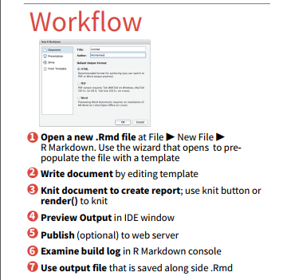

The second shows a summary of how to integrate blocks of code (programming) in your document.

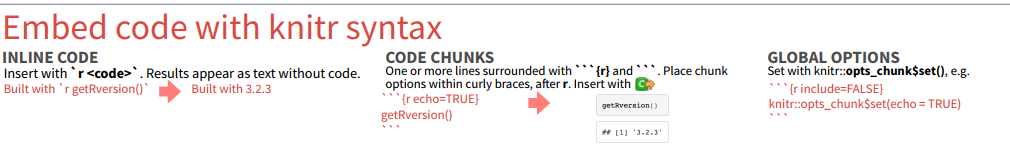

The third region shows part of the list of foratting codes and the printed effects they create. This is the Pandoc part of R Markdown. It creates the text effects we want to see. The effects we can use here are not available in the code sections of the document.

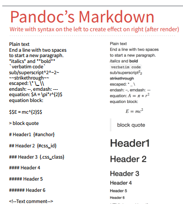

## Elements of R Markdown

An R Markdown document has three elements: YAML, blocks of text and blocks of code. The first tells RStudio and the RMarkdown package (loaded automatically when you downloaded RStudio) what they must do when you *knit* the document. *Knit* a document means to produce a version in *html*, *pdf* or Word.

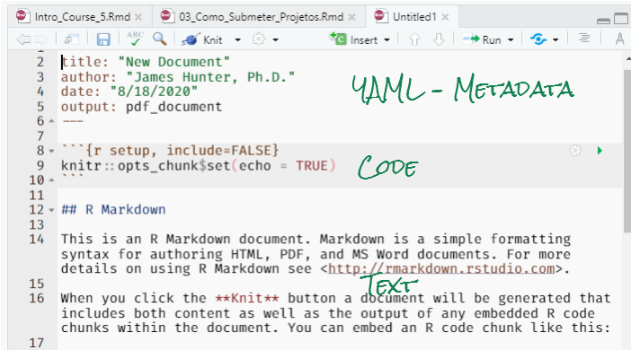

### YAML – The Document Header

An R Markdown document must begin with the section written in the YAML language. YAML stands for “Yet Another Markup Language” or “YAML Ain’t Markup Language”, depending on how sarcastic the inventor is feeling on a given day. The YAML header contains the metadata that act like an address block on an envelope. The fields you insert here tell RStudio where to send the document (to the HTML renderer, PDF or to Word) and how.

Metadata are data about the document not data that form part of the document. This chapter talks about R Markdown and R projects. However, the YAML section talks about how the document should be formatted, not its content.

[figure not shown]

The YAML section begins and ends with three hyphens on a line (`---`). In between, it will have a number of lines that contain instructions in the format <`key`> : <`value`>.

#### Complexity of YAML

The YAML header can be as simple or complex as you want. The simple version has the format of the new document example above. There, we have a title, the author, the date and the type of output that RStudio should produce. In that case, the output of *knit* will go to a *pdf* document via the Latex rendering system.

The YAML for this chapter is more complicated. Here, we have the title and author as before. However, now the date field takes advantage of the ability of R Markdown to incorporate code directly into text, what RStudio refers to as *inline* code.

As well, I have created the option to produce either an html or pdf document (the lines that have the “output” key, `output:html_document` and `output:pdf_document`). Both options will include a table of contents (`toc: yes`). If the html document needs to print data frames, it will paginate them (`df_print: paged`) rather than letting them run on.

#### R Markdown Document Themes

There is one more line in the html block of the YAML: `theme: flatly`. You can have a great deal of control over the look, the colors and the fonts that *knitr* will use to print your document by specifying a theme. These themes com from an internet library of themes called Bootswatch[^7]. Bootswatch is part of the website development system, Bootstrap. The themes available in R Markdown are

- default
- cerulean
- journal
- flatly
- darkly
- readable
- spacelab
- united
- cosmo
- lumen
- paper
- sandstone
- simplex
- yeti

You can find examples of the fonts and colors used in the themes on the Bootswatch site.

#### Types of Output

This chapter has emphasized text documents, but there are many other themes and types of output, including slides, pamphlets, sites, blogs and books. You can find a list of the available outputs at the R Markdown site https://rmarkdown.rstudio.com/docs/reference/index.html#section-output-formats.

### Code Blocks

Programming statements that you want R to process are set out in special blocks. Everything in these blocks passes through the R interpreter and everything outside does not. A code block has a specific structure that must be followed exactly.

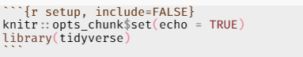

A code block starts with three backticks (*acentos graves* - “```”) followed by `{r }` on the first line. In the example above, the first line also has a name for the block and an instruction (`include=FALSE`). You should name all your code blocks so you can find them if you need to refer to them. They may also have a number of arguments. You can find the possible arguments on the R Markdown cheatsheet. The block must also end with three backticks on a line by themselves.

Generally, the first block of code after the YAML header should be a “setup” block that specifies some of the parameters that you want to apply to the entire document and can, as above, load some of the packages you will be using while developing the document. Here, I have loaded the `tidyverse` set of packages (`library(tidyverse)`) to make them available throughout the document. Many of the parameters that come from the `knitr` package are advanced and need not concern you at this point. The first line instructs `knitr` to print out (i.e., `echo`) the code in the code blocks for the reader to see.

What you set up in this initial block can be changed as you develop your document. You can override a document-wide parameter in a given block. For example, if I want to calculate something, but not show the process to the reader, I can use in the header of a block the parameter `echo = FALSE`, which will suppress rendering of the code.

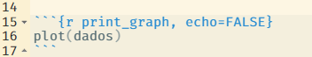

### Text Blocks

This is where you write the text of your document. You can use all the formatting options shown in the PANDOC figure above and on the R Markdown cheatsheet. You can create a structure for your text with different headers. Place from 1 to 6 hashtag symbols (`#`) at the beginning of the line to show the level of the header. Remember to leave a space between the last hashtag and the beginning of the header text.

**VSS:** When you move from a block of text to a block of code or vice versa, leave two lines beween the blocks.

## Document Production

When your document is ready to be printed or tested (something I recommend you do frequently), you can click the word `Knit` create the final document in the format you specified in the `output:` field in the YAML header or selected in the `Knit` menu. RStudio will open an “R Markdown” window beside the Console where it will show your progress and any errors or problems it encounters.

If RStudio does find an error, it will advise you in what line of the document it occurred and what was the type of the error. You will need to fix the error and try the `Knit` again. If this window shows that the output was created, you are done. RStudio will produce a copy of the final product. If you want to modify its appearance, you make a change to the document and `Knit` it again. Normally, it will take more than one `Knit` to achieve the result you want. A little patience will yield a pleasing result.

[^1]: `getwd()` has a companion function `setwd()` that allows you to make the directory where you are currently located into the working directory if it is not already. However, you will see below that use of this command is discouraged.
[^2]: This is a reminder footnote to back up your data and research files regularly. I maintain 3 backups for my thesis, one in the Cloud, one on a pen drive and a third on an external hard disk. To quote the great sages of Texas: “Too much ain’t enough!”
[^3]: Xie, Y, Allaire, JJ, Grolemund, G, **R Markdown: The Definitive Guide**, 2020, https://bookdown.org/yihui/rmarkdown/.
[^4]: Tierney, N., **R Markdown for Scientists**, 2020, https://rmd4sci.njtierney.com/
[^5]: **An Introduction to R Markdown**, https://rstd.io/rmd4cdc.
[^6]: Wikipedia contributors. Markdown. Wikipedia, The Free Encyclopedia. June 3, 2020, 02:02 UTC. Available at: https://en.wikipedia.org/w/index.php?title=Markdown&oldid=960453793. Accessed August 18, 2020.
[^7]: https://bootswatch.com/3/